# Lecture 28: The Normal Distribution

Associated Textbook Sections: [14.3, 14.4](https://ccsf-math-108.github.io/textbook/chapters/14/3/SD_and_the_Normal_Curve.html)

## Outline

- Standard Units Review
- Normal Distributions
- Normal Proportions

## Set Up the Notebook

```python
from datascience import *
import numpy as np
%matplotlib inline
import matplotlib.pyplot as plt
plt.style.use('fivethirtyeight')
import scipy
import plotly.express as px
from ipywidgets import interact, interactive, fixed, interact_manual
import ipywidgets as widgets
```

## Standard Units Review

- How many SDs above average?
- `z = (value - average)/SD`
  - Negative z: value below average
  - Positive z: value above average
  - z = 0: value equal to average
- When values are in standard units: average = 0, SD = 1
- Gives us a way to compare/understand data no matter what the original units

### Demo: Standard Units

- Load UC Berkeley DATA 8 exam distribution data from Fall 2018.
- Calculate the mean midterm and final exam scores.
- Visualize the distribution of scores.
- Create a function that calculates the standard units of the numerical values in an array.
- Add the standardized midterm and final exam scores to the `exams` table.
- Visualize the distribution of standardized scores to notice that the general shape of the distribution does not change.

```python
exams = Table.read_table('exams_fa18.csv')
exams.show(5)
```

| Midterm | Final |
| --- | --- |
| 91 | 88 |
| 89.5 | 84 |
| 78 | 71.5 |
| 87 | 88 |
| 72 | 72.5 |

... (1237 rows omitted)

```python
midterm_mean = np.mean(exams.column('Midterm'))
final_mean = np.mean(exams.column('Final'))
midterm_mean, final_mean
```

```
(77.832528180199347, 79.207729468599027)
```

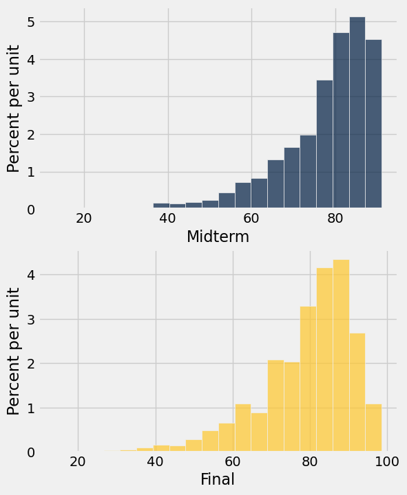

```python
(exams
 .select('Midterm', 'Final')
 .hist(overlay=False, bins=20))
```

```python
np.min(exams.column('Final'))
```

```
14.000000000000002
```

```python
def standard_units(x):
    """Convert array x to standard units."""
    return (x - np.mean(x)) / np.std(x)
```

```python
midterm_su = standard_units(exams.column('Midterm'))
exams = exams.with_column('Midterm in Standard Units', midterm_su)

final_su = standard_units(exams.column('Final'))
exams = exams.with_column('Final in Standard Units', final_su)

exams.show(10)
```

| Midterm | Final | Midterm in Standard Units | Final in Standard Units |
| --- | --- | --- | --- |
| 91 | 88 | 1.16278 | 0.717241 |
| 89.5 | 84 | 1.03032 | 0.390935 |
| 78 | 71.5 | 0.0147889 | -0.628768 |
| 87 | 88 | 0.809552 | 0.717241 |
| 72 | 72.5 | -0.515053 | -0.547191 |
| 71.5 | 61 | -0.559206 | -1.48532 |
| 82 | 92.5 | 0.368017 | 1.08433 |
| 84.5 | 87 | 0.588784 | 0.635664 |
| 85 | 92 | 0.632938 | 1.04355 |
| 78 | 71 | 0.0147889 | -0.669556 |

... (1232 rows omitted)

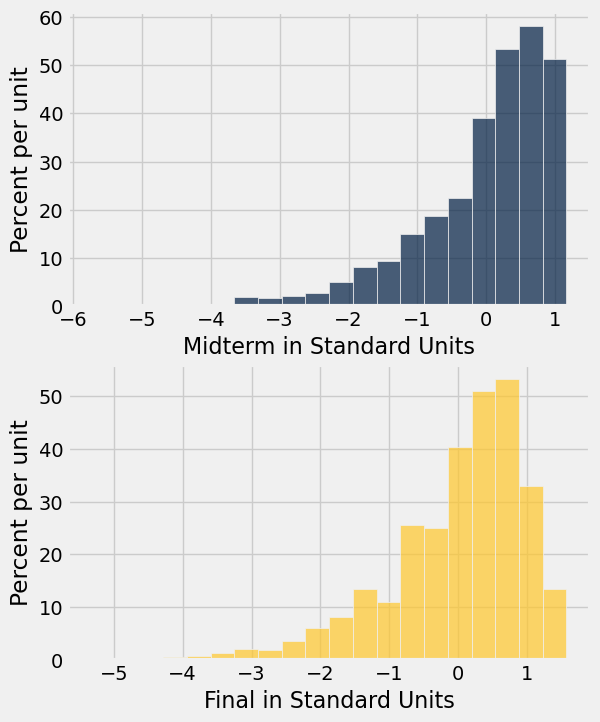

```python
exams.select(
    'Midterm in Standard Units', 'Final in Standard Units'
).hist(overlay=False, bins=20)
```

## Normal Distributions

### Bell-Shaped Curves

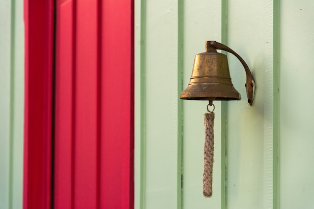

### There are many, many, many normal curves!

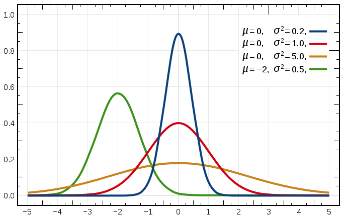

### Probability Density Curve

The height of the (probability density) curves are determined by the formula*

$$f(x) = \frac{1}{\sigma\sqrt{2\pi}}e^{-\frac{1}{2}\left(\frac{x - \mu}{\sigma}\right)^2}$$

and the shape is determined by the mean (`mu`, $\mu$) and standard deviation (`sigma`, $\sigma$) values.

*Note: You will not be working with this formula directly in this class, but we can use a python representation of it (`scipy.stats.norm.pdf`) to see how the mean and standard deviation impact the shape of the distribution.*

```python
def graph_norm(mu=0, sigma=1):
    x=np.arange(-10, 10, 0.01)
    display(px.line(x=x,
                    y=scipy.stats.norm.pdf(x, loc=mu, scale=sigma),
                    range_y=[0, 1]));
```

Adjust the values of `mu` and `sigma` using the slider to see how the shape of the distribution changes.

```python
interact(graph_norm, mu=(-5, 5), sigma=(0.2**0.5, 5**0.5, 0.05));
```

```
interactive(children=(IntSlider(value=0, description='mu', max=5, min=-5), FloatSlider(value=1.0, description=…
```

## Normal Proportions

### How Big are Most of the Values?

- No matter what the shape of the distribution, the bulk of the data are in the range "average ± a few SDs" (Chebyshev's Inequality)
- **If a histogram is bell-shaped**, then almost all of the data are in the range "average ± 3 SDs"

### Bounds and Normal Approximations

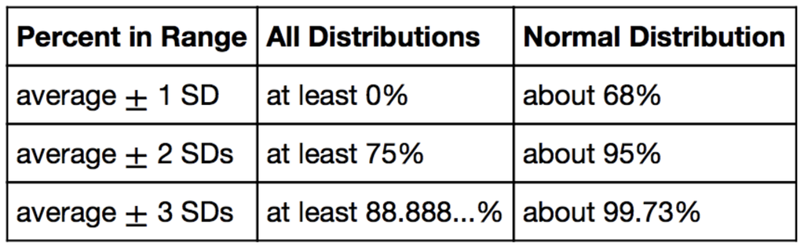

### A "Central" Area

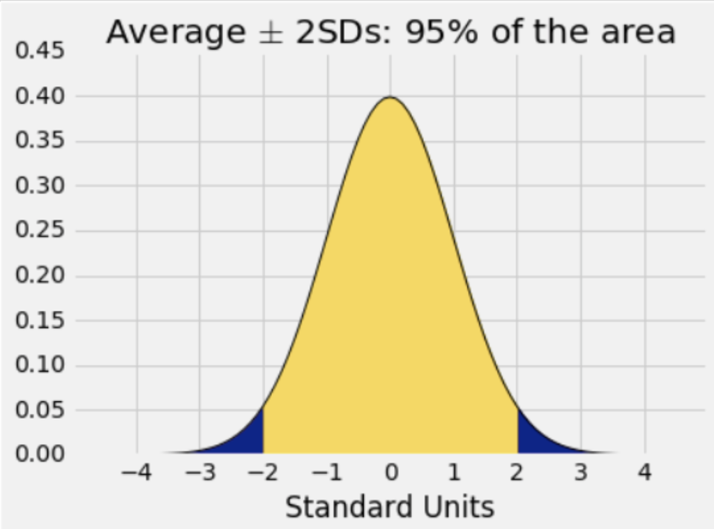

## Attribution

This content is licensed under the Creative Commons Attribution-NonCommercial-ShareAlike 4.0 International License (CC BY-NC-SA 4.0) and derived from the Data 8: The Foundations of Data Science offered by the University of California, Berkeley.